# Census_Income Project

The Census Income Project, in addition to traditional survey methods, can leverage machine learning algorithms to enhance its analysis and prediction capabilities. By incorporating machine learning techniques, the project can extract valuable insights from the collected data and make predictions related to income levels or other socioeconomic factors.

Machine learning algorithms can be applied to various aspects of the Census Income Project, such as:

Data preprocessing: Machine learning algorithms can assist in cleaning and preprocessing the collected data, handling missing values, and transforming variables into suitable formats for analysis.

Feature selection: Machine learning algorithms can automatically identify the most relevant features or variables that contribute to predicting income levels. This process helps to reduce dimensionality and focus on the most informative attributes.

Predictive modeling: Machine learning algorithms, such as decision trees, random forests, logistic regression, support vector machines, or neural networks, can be used to build predictive models that estimate income levels based on demographic, employment, and educational features.

```python
# import numpy as np
import matplotlib.pyplot as plt
import seaborn as sns
import pandas as pd
import warnings
warnings.filterwarnings('ignore')
```

```python
df=pd.read_csv(r"D:\census_income Project\census.csv")
```

```python
df.head()
```

|  | age | workclass | fnlwgt | education | education-num | marital-status | occupation | relationship | race | sex | capital-gain | capital-loss | hours-per-week | native-country | income |
| --- | --- | --- | --- | --- | --- | --- | --- | --- | --- | --- | --- | --- | --- | --- | --- |
| 0 | 25 | Private | 226802 | 11th | 7 | Never-married | Machine-op-inspct | Own-child | Black | Male | 0 | 0 | 40 | United-States | <=50K |
| 1 | 38 | Private | 89814 | HS-grad | 9 | Married-civ-spouse | Farming-fishing | Husband | White | Male | 0 | 0 | 50 | United-States | <=50K |
| 2 | 28 | Local-gov | 336951 | Assoc-acdm | 12 | Married-civ-spouse | Protective-serv | Husband | White | Male | 0 | 0 | 40 | United-States | >50K |
| 3 | 44 | Private | 160323 | Some-college | 10 | Married-civ-spouse | Machine-op-inspct | Husband | Black | Male | 7688 | 0 | 40 | United-States | >50K |
| 4 | 18 | ? | 103497 | Some-college | 10 | Never-married | ? | Own-child | White | Female | 0 | 0 | 30 | United-States | <=50K |

```python
print(f'Number of Rows:{df.shape[0]}')
print(f'Number of Columns: {df.shape[1]}')
```

```
Number of Rows:48842
Number of Columns: 15
```

```python
for i, col in enumerate(df.columns):
    print(df.columns[i], '::\n', df[str(col)].unique(),'\n\n')
```

```
age ::
 [25 38 28 44 18 34 29 63 24 55 65 36 26 58 48 43 20 37 40 72 45 22 23 54
 32 46 56 17 39 52 21 42 33 30 47 41 19 69 50 31 59 49 51 27 57 61 64 79
 73 53 77 80 62 35 68 66 75 60 67 71 70 90 81 74 78 82 83 85 76 84 89 88
 87 86]


workclass ::
 ['Private' 'Local-gov' '?' 'Self-emp-not-inc' 'Federal-gov' 'State-gov'
 'Self-emp-inc' 'Without-pay' 'Never-worked']


fnlwgt ::
 [226802  89814 336951 ... 129912 255835 257302]


education ::
 ['11th' 'HS-grad' 'Assoc-acdm' 'Some-college' '10th' 'Prof-school'
 '7th-8th' 'Bachelors' 'Masters' 'Doctorate' '5th-6th' 'Assoc-voc' '9th'
 '12th' '1st-4th' 'Preschool']


education-num ::
 [ 7  9 12 10  6 15  4 13 14 16  3 11  5  8  2  1]


marital-status ::
 ['Never-married' 'Married-civ-spouse' 'Widowed' 'Divorced' 'Separated'
 'Married-spouse-absent' 'Married-AF-spouse']


occupation ::
 ['Machine-op-inspct' 'Farming-fishing' 'Protective-serv' '?'
 'Other-service' 'Prof-specialty' 'Craft-repair' 'Adm-clerical'
 'Exec-managerial' 'Tech-support' 'Sales' 'Priv-house-serv'
 'Transport-moving' 'Handlers-cleaners' 'Armed-Forces']


relationship ::
 ['Own-child' 'Husband' 'Not-in-family' 'Unmarried' 'Wife' 'Other-relative']
```

[output cut: 39 more lines]

```
 19 98 62 66 57 11 86 59  9 64 73 61 88 79 89 74 69 87 97 94 82 91 81 95]


native-country ::
 ['United-States' '?' 'Peru' 'Guatemala' 'Mexico' 'Dominican-Republic'
 'Ireland' 'Germany' 'Philippines' 'Thailand' 'Haiti' 'El-Salvador'
 'Puerto-Rico' 'Vietnam' 'South' 'Columbia' 'Japan' 'India' 'Cambodia'
 'Poland' 'Laos' 'England' 'Cuba' 'Taiwan' 'Italy' 'Canada' 'Portugal'
 'China' 'Nicaragua' 'Honduras' 'Iran' 'Scotland' 'Jamaica' 'Ecuador'
 'Yugoslavia' 'Hungary' 'Hong' 'Greece' 'Trinadad&Tobago'
 'Outlying-US(Guam-USVI-etc)' 'France' 'Holand-Netherlands']


income ::
 ['<=50K' '>50K']
```

```python
df.describe()
```

|  | age | fnlwgt | education-num | capital-gain | capital-loss | hours-per-week |
| --- | --- | --- | --- | --- | --- | --- |
| count | 48842.000000 | 4.884200e+04 | 48842.000000 | 48842.000000 | 48842.000000 | 48842.000000 |
| mean | 38.643585 | 1.896641e+05 | 10.078089 | 1079.067626 | 87.502314 | 40.422382 |
| std | 13.710510 | 1.056040e+05 | 2.570973 | 7452.019058 | 403.004552 | 12.391444 |
| min | 17.000000 | 1.228500e+04 | 1.000000 | 0.000000 | 0.000000 | 1.000000 |
| 25% | 28.000000 | 1.175505e+05 | 9.000000 | 0.000000 | 0.000000 | 40.000000 |
| 50% | 37.000000 | 1.781445e+05 | 10.000000 | 0.000000 | 0.000000 | 40.000000 |
| 75% | 48.000000 | 2.376420e+05 | 12.000000 | 0.000000 | 0.000000 | 45.000000 |
| max | 90.000000 | 1.490400e+06 | 16.000000 | 99999.000000 | 4356.000000 | 99.000000 |

```python
df.info()
```

```
<class 'pandas.core.frame.DataFrame'>
RangeIndex: 48842 entries, 0 to 48841
Data columns (total 15 columns):
 #   Column          Non-Null Count  Dtype
---  ------          --------------  -----
 0   age             48842 non-null  int64
 1   workclass       48842 non-null  object
 2   fnlwgt          48842 non-null  int64
 3   education       48842 non-null  object
 4   education-num   48842 non-null  int64
 5   marital-status  48842 non-null  object
 6   occupation      48842 non-null  object
 7   relationship    48842 non-null  object
 8   race            48842 non-null  object
 9   sex             48842 non-null  object
 10  capital-gain    48842 non-null  int64
 11  capital-loss    48842 non-null  int64
 12  hours-per-week  48842 non-null  int64
 13  native-country  48842 non-null  object
 14  income          48842 non-null  object
dtypes: int64(6), object(9)
memory usage: 5.6+ MB
```

```python
df.columns
```

```
Index(['age', 'workclass', 'fnlwgt', 'education', 'education-num',
       'marital-status', 'occupation', 'relationship', 'race', 'sex',
       'capital-gain', 'capital-loss', 'hours-per-week', 'native-country',
       'income'],
      dtype='object')
```

```python
df.isnull().sum()
```

```
age               0
workclass         0
fnlwgt            0
education         0
education-num     0
marital-status    0
occupation        0
relationship      0
race              0
sex               0
capital-gain      0
capital-loss      0
hours-per-week    0
native-country    0
income            0
dtype: int64
```

```python
df.isin(['?']).sum(axis=0)
```

```
age                  0
workclass         2799
fnlwgt               0
education            0
education-num        0
marital-status       0
occupation        2809
relationship         0
race                 0
sex                  0
capital-gain         0
capital-loss         0
hours-per-week       0
native-country     857
income               0
dtype: int64
```

```python
df.replace("?",np.nan, inplace=True)
```

```python
df.isnull().sum()
```

```
age                  0
workclass         2799
fnlwgt               0
education            0
education-num        0
marital-status       0
occupation        2809
relationship         0
race                 0
sex                  0
capital-gain         0
capital-loss         0
hours-per-week       0
native-country     857
income               0
dtype: int64
```

```python
df=df.dropna()
df
```

|  | age | workclass | fnlwgt | education | education-num | marital-status | occupation | relationship | race | sex | capital-gain | capital-loss | hours-per-week | native-country | income |
| --- | --- | --- | --- | --- | --- | --- | --- | --- | --- | --- | --- | --- | --- | --- | --- |
| 0 | 25 | Private | 226802 | 11th | 7 | Never-married | Machine-op-inspct | Own-child | Black | Male | 0 | 0 | 40 | United-States | <=50K |
| 1 | 38 | Private | 89814 | HS-grad | 9 | Married-civ-spouse | Farming-fishing | Husband | White | Male | 0 | 0 | 50 | United-States | <=50K |
| 2 | 28 | Local-gov | 336951 | Assoc-acdm | 12 | Married-civ-spouse | Protective-serv | Husband | White | Male | 0 | 0 | 40 | United-States | >50K |
| 3 | 44 | Private | 160323 | Some-college | 10 | Married-civ-spouse | Machine-op-inspct | Husband | Black | Male | 7688 | 0 | 40 | United-States | >50K |
| 5 | 34 | Private | 198693 | 10th | 6 | Never-married | Other-service | Not-in-family | White | Male | 0 | 0 | 30 | United-States | <=50K |
| ... | ... | ... | ... | ... | ... | ... | ... | ... | ... | ... | ... | ... | ... | ... | ... |
| 48837 | 27 | Private | 257302 | Assoc-acdm | 12 | Married-civ-spouse | Tech-support | Wife | White | Female | 0 | 0 | 38 | United-States | <=50K |
| 48838 | 40 | Private | 154374 | HS-grad | 9 | Married-civ-spouse | Machine-op-inspct | Husband | White | Male | 0 | 0 | 40 | United-States | >50K |
| 48839 | 58 | Private | 151910 | HS-grad | 9 | Widowed | Adm-clerical | Unmarried | White | Female | 0 | 0 | 40 | United-States | <=50K |
| 48840 | 22 | Private | 201490 | HS-grad | 9 | Never-married | Adm-clerical | Own-child | White | Male | 0 | 0 | 20 | United-States | <=50K |
| 48841 | 52 | Self-emp-inc | 287927 | HS-grad | 9 | Married-civ-spouse | Exec-managerial | Wife | White | Female | 15024 | 0 | 40 | United-States | >50K |

45222 rows × 15 columns

```python
df.isna().sum()
```

```
age               0
workclass         0
fnlwgt            0
education         0
education-num     0
marital-status    0
occupation        0
relationship      0
race              0
sex               0
capital-gain      0
capital-loss      0
hours-per-week    0
native-country    0
income            0
dtype: int64
```

```python
df['income_num']=df['income'].map({'<=50K':0, '>50K':1})
```

```python
below_50k=(df.income_num==0).sum()
print(below_50k)
```

```
34014
```

```python
above_50k=(df.income_num==1).sum()
print(above_50k)
```

```
11208
```

```python
pd.crosstab(df['native-country'],df['income'],
           values=df['hours-per-week'], aggfunc=np.mean)
```

| income native-country | <=50K | >50K |
| --- | --- | --- |
| Cambodia | 41.294118 | 43.888889 |
| Canada | 38.475728 | 46.933333 |
| China | 37.753247 | 42.027778 |
| Columbia | 39.538462 | 56.250000 |
| Cuba | 39.919192 | 42.852941 |
| Dominican-Republic | 41.717391 | 42.800000 |
| Ecuador | 39.081081 | 47.833333 |
| El-Salvador | 36.014706 | 43.454545 |
| England | 40.722222 | 46.297872 |
| France | 41.350000 | 46.500000 |
| Germany | 39.251852 | 45.706897 |
| Greece | 41.870968 | 55.555556 |
| Guatemala | 38.759036 | 36.666667 |
| Haiti | 37.166667 | 40.666667 |
| Holand-Netherlands | 40.000000 | NaN |
| Honduras | 35.058824 | 50.000000 |
| Hong | 38.900000 | 43.750000 |
| Hungary | 33.583333 | 46.333333 |
| India | 38.729412 | 46.274194 |
| Iran | 41.058824 | 47.954545 |
| Ireland | 41.269231 | 45.700000 |
| Italy | 39.119403 | 45.818182 |
| Jamaica | 38.764045 | 41.857143 |
| Japan | 39.896552 | 47.129032 |
| Laos | 40.315789 | 40.000000 |
| Mexico | 40.225467 | 45.638298 |
| Nicaragua | 36.777778 | 38.333333 |
| Outlying-US(Guam-USVI-etc) | 41.476190 | 40.000000 |
| Peru | 36.609756 | 40.000000 |
| Philippines | 38.105528 | 43.630952 |
| Poland | 38.384615 | 39.562500 |
| Portugal | 41.280000 | 46.750000 |
| Puerto-Rico | 38.741935 | 39.900000 |
| Scotland | 40.833333 | 50.000000 |
| South | 43.518072 | 51.000000 |
| Taiwan | 37.066667 | 45.760000 |
| Thailand | 44.333333 | 53.000000 |
| Trinadad&Tobago | 38.750000 | 40.000000 |
| United-States | 39.369245 | 45.718989 |
| Vietnam | 38.618421 | 39.428571 |
| Yugoslavia | 38.533333 | 43.375000 |

[figure not shown]

```python
sns.countplot(df.income_num)
df.income_num.value_counts()
plt.title('Income Above and Below 50K', fontsize=15)
plt.xlabel('Income',fontsize=15)
plt.ylabel('Count',fontsize=15)
```

# Occupation vs Income

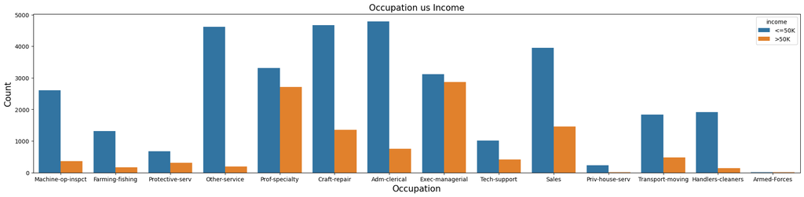

```python
occupation, axes=plt.subplots(1,1,figsize=(24,5))
sns.countplot(data=df,x='occupation',hue='income')
plt.title('Occupation us Income',fontsize=15)
plt.xlabel('Occupation',fontsize=15)
plt.ylabel('Count',fontsize=15)
plt.show()
```

# Workclass vs Income

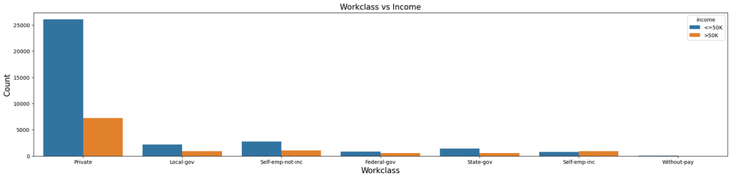

```python
occupation, axes=plt.subplots(1,1,figsize=(24,5))
sns.countplot(data=df,x='workclass',hue='income')
plt.title('Workclass vs Income', fontsize=15)
plt.xlabel('Workclass',fontsize=15)
plt.ylabel('Count',fontsize=15)
plt.show()
```

# Relation vs Income

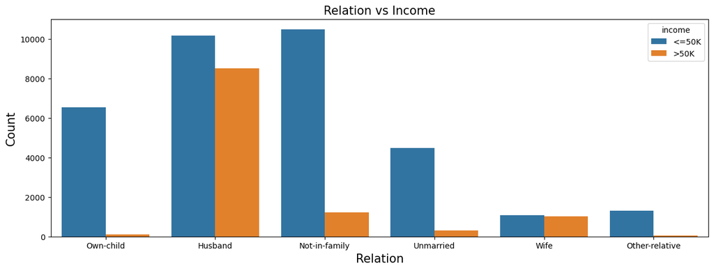

```python
realtion, axes=plt.subplots(1,1, figsize=(15,5))
sns.countplot(data=df, x='relationship',hue='income')
plt.title('Relation vs Income',fontsize=15)
plt.xlabel('Relation',fontsize=15)
plt.ylabel('Count',fontsize=15)
plt.show()
```

# Education Vs Income

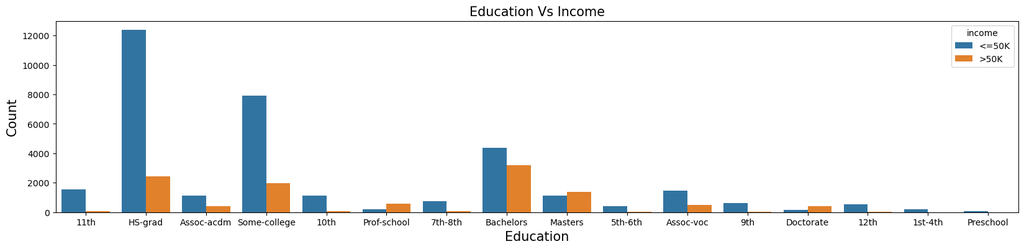

```python
education, axes =plt.subplots(1,1, figsize=(20,4))
sns.countplot(data=df, x='education',hue='income')
plt.title('Education Vs Income',fontsize=15)
plt.xlabel('Education',fontsize=15)
plt.ylabel('Count',fontsize=15)
plt.show()
```

# Sex vs Income

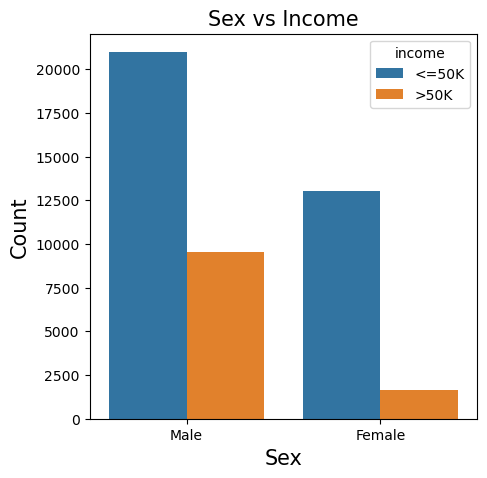

```python
sex, axes=plt.subplots(1,1,figsize=(5,5))
sns.countplot(data=df, x='sex',hue='income')
plt.title('Sex vs Income',fontsize=15)
plt.xlabel('Sex',fontsize=15)
plt.ylabel('Count',fontsize=15)
plt.show()
```

# Race vs Income

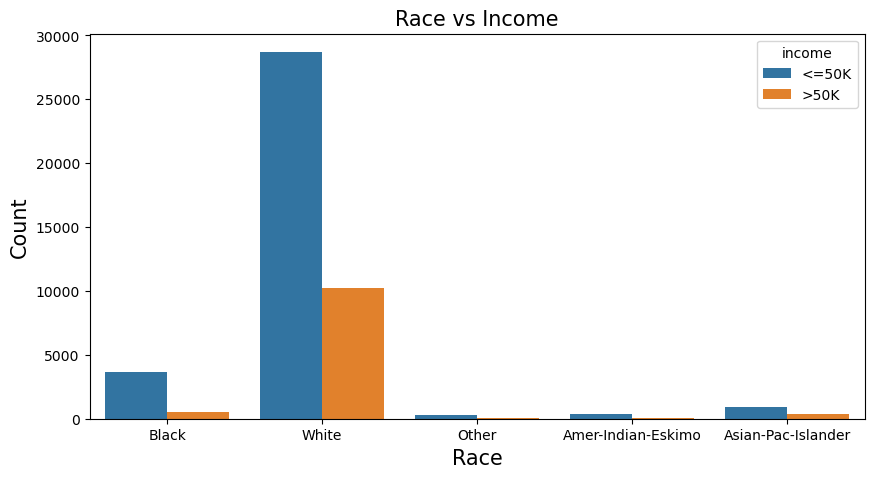

```python
race, axes=plt.subplots(1,1,figsize=(10,5))
sns.countplot(data=df,x='race',hue='income')
plt.title('Race vs Income',fontsize=15)
plt.xlabel('Race',fontsize=15)
plt.ylabel('Count',fontsize=15)
plt.show()
```

# Precentage of Race

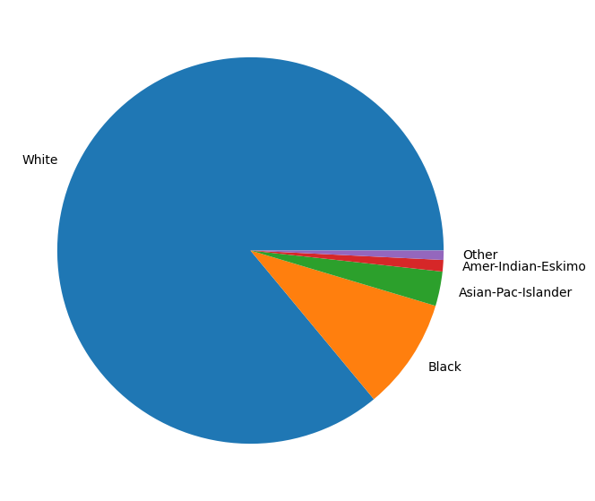

```python
label=df.race.value_counts().index
count=df.race.value_counts().values
plt.figure(1, figsize=(7,7))
plt.pie(count,labels=label)
plt.show()
```

# Percentage of sex

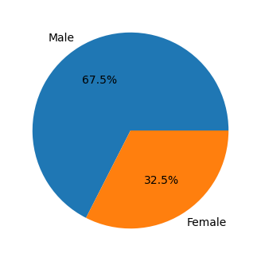

```python
label=df.sex.value_counts().index
count=df.sex.value_counts().values
plt.figure(1, figsize=(4,4))
plt.pie(count,labels=label,autopct='%1.1f%%')
plt.show()
```

# Age Distribution

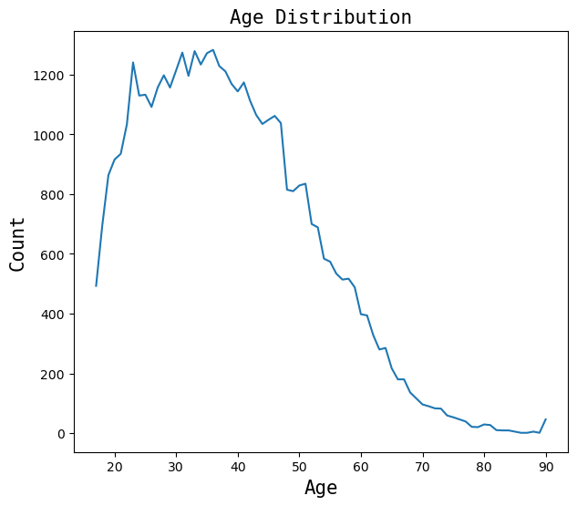

```python
#Height and Width
size=plt.figure()
size.set_figwidth(7)
size.set_figheight(6)

plt.title("Age Distribution",fontdict={"fontname":"monospace","fontsize":15})
plt.xlabel("Age",fontdict={"fontname":"monospace","fontsize":15})
plt.ylabel("Count",fontdict={"fontname":"monospace","fontsize":15})
df['age'].value_counts().sort_index().plot.line()
```